# Statistical machine learning, Lab 1

The aim of this lab is to learn to use R for data input, exploration and visualization. You can learn more about the tools we are using from the book [R for Data Science](https://r4ds.had.co.nz/) and for quick reference a good resource is collection of cheat sheets from RStudio website: https://www.rstudio.com/resources/cheatsheets/

## Libraries

It is important to keep in mind that R is a collection of main functionality (base R) and various packages and often it is possible to achieve the same goals by using different commands from different packages. Our main package (actually a collection of different packages which work together) is `tidyverse` package. It is a good idea to load all required libraries in a separate code block (setup chunk) and packages are loaded with `library(library_name)` command. If a library is not available, it should be installed by using `install.packages("package_name")` command.

- **Exercise 1**: load `tidyverse`, `tidymodels` and `GGally` packages (install it if necessary)

```r
library(tidyverse)
library(tidymodels)
library(GGally)
```

## Getting data into R

Data can be in many formats (text files, spreadsheets, SAS/STATA/SPSS data files and so on) and each format requires a different function which is able to understand it. Fortunately there are libraries of such commands available for most common formats, but we’ll consider only text files (for example .csv files).

We consider only data which is in tabular format.

### Reading data from text files

The most universal command in the `tidyverse` for this purpose is `read_delim`, which can be used for all files for which fields are delimited by a single character. For successful reading of data we should know how missing data is represented, what is separator of fields and what is decimal separator. If data fail is not extremely large, a good program for determining those features visually is Notepad++ for Windows. An alternative which is also available for Mac and Linux is Sublime Text editor (where you have to select a part of text to see invisible characters).

Some moste useful options of this command are:

- `delim='x'` (here x is the symbol for delimiter, ’ for tabulator)
- `skip=n` (used for leaving out certain number of rows from the beginning)
- `col_names=FALSE` if the file does not include column names
- `na=c('..','NA',...)` if missing values are denoted by some text
- `n_max=n` (maximal number of lines to read, used for skipping lines at the end of file)
- `locale = locale(decimal_mark = ",")` for indicating what is used for decimal separator
- **Exercise 2**: Download from Moodle datasets of Lab1 and read into R the dataset `Auto.csv`, `AZN.csv`,`AMZN.csv` by using the command `read_delim`

*Solution*: Auto: After looking at the content of the file, we see, that fields are separated ty `,`.

```r
Auto1=read_delim("Auto.csv",delim=",")
Auto1
```

| mpg | cylinders | displacement | horsepower | weight | acceleration | year | origin | name |
| --- | --- | --- | --- | --- | --- | --- | --- | --- |
| 18.0 | 8 | 307.0 | 130 | 3504 | 12.0 | 70 | 1 | chevrolet chevelle malibu |
| 15.0 | 8 | 350.0 | 165 | 3693 | 11.5 | 70 | 1 | buick skylark 320 |
| 18.0 | 8 | 318.0 | 150 | 3436 | 11.0 | 70 | 1 | plymouth satellite |
| 16.0 | 8 | 304.0 | 150 | 3433 | 12.0 | 70 | 1 | amc rebel sst |
| 17.0 | 8 | 302.0 | 140 | 3449 | 10.5 | 70 | 1 | ford torino |
| 15.0 | 8 | 429.0 | 198 | 4341 | 10.0 | 70 | 1 | ford galaxie 500 |
| 14.0 | 8 | 454.0 | 220 | 4354 | 9.0 | 70 | 1 | chevrolet impala |
| 14.0 | 8 | 440.0 | 215 | 4312 | 8.5 | 70 | 1 | plymouth fury iii |
| 14.0 | 8 | 455.0 | 225 | 4425 | 10.0 | 70 | 1 | pontiac catalina |
| 15.0 | 8 | 390.0 | 190 | 3850 | 8.5 | 70 | 1 | amc ambassador dpl |

[output cut: 382 more lines]

AZN: Delimiter is comma, first line is not part of data. We can make R to ignore it by `skip=1` or we can indicate that lines starting with `*` should be ignored with `comment='*'`

```r
AZN=read_delim("AZN.csv",delim=",",comment='*')
AZN
```

| Date | Open | High | Low | Close | Adj Close | Volume |
| --- | --- | --- | --- | --- | --- | --- |
| 2020-08-31 | 55.80 | 56.34 | 55.61 | 56.00 | 54.50141 | 3262600 |
| 2020-09-01 | 55.85 | 55.90 | 55.12 | 55.38 | 53.89801 | 3943100 |
| 2020-09-02 | 55.47 | 55.99 | 55.27 | 55.90 | 54.40409 | 3614200 |
| 2020-09-03 | 55.35 | 55.50 | 53.61 | 54.16 | 52.71066 | 5122000 |
| 2020-09-04 | 53.79 | 54.14 | 52.57 | 53.58 | 52.14617 | 4610000 |
| 2020-09-08 | 54.14 | 54.94 | 53.76 | 54.71 | 53.24593 | 6735600 |
| 2020-09-09 | 53.83 | 54.82 | 53.34 | 53.64 | 52.20457 | 11416300 |
| 2020-09-10 | 54.16 | 54.19 | 53.04 | 53.07 | 51.64982 | 4407100 |
| 2020-09-11 | 53.99 | 54.15 | 53.41 | 53.73 | 52.29216 | 4627700 |
| 2020-09-14 | 54.23 | 54.34 | 53.37 | 54.02 | 52.57440 | 4960000 |

[output cut: 242 more lines]

AMZN: field separator is tabulator symbol (can be indicated with `delim='\t'`). Fractional part of numbers is indicated with `,` (decimal separator), at the end of file are lines which do not contain data.

```r
AMZN=read_delim("AMZN.csv",delim="\t",locale = locale(decimal_mark = ","),n_max = 252)
AMZN
```

| Date | Open | High | Low | Close | Adj Close | Volume |
| --- | --- | --- | --- | --- | --- | --- |
| 2020-08-31 | 3408.99 | 3495.00 | 3405.00 | 3450.96 | 3450.96 | 4185900 |
| 2020-09-01 | 3489.58 | 3513.87 | 3467.00 | 3499.12 | 3499.12 | 3432200 |
| 2020-09-02 | 3547.00 | 3552.25 | 3486.69 | 3531.45 | 3531.45 | 3931500 |
| 2020-09-03 | 3485.00 | 3488.41 | 3303.00 | 3368.00 | 3368.00 | 8161100 |
| 2020-09-04 | 3318.00 | 3381.50 | 3111.13 | 3294.62 | 3294.62 | 8781800 |
| 2020-09-08 | 3144.00 | 3250.85 | 3130.00 | 3149.84 | 3149.84 | 6094200 |
| 2020-09-09 | 3202.99 | 3303.18 | 3185.00 | 3268.61 | 3268.61 | 5188700 |
| 2020-09-10 | 3307.22 | 3349.89 | 3170.55 | 3175.11 | 3175.11 | 5330700 |
| 2020-09-11 | 3208.69 | 3217.34 | 3083.98 | 3116.22 | 3116.22 | 5094000 |
| 2020-09-14 | 3172.94 | 3187.39 | 3096.00 | 3102.97 | 3102.97 | 4529600 |

[output cut: 242 more lines]

- **Exercise 3**: After reading data in, it may be a good idea to look at the data by typing `View(dataset)` in console window and also to compute some summary information by `summary(dataset)` command. Look at the summary information of dataset read in from `Auto.csv`. Are minimal and maximal weights realistic?

*Solution*

```r
summary(Auto1)
```

```
##       mpg          cylinders      displacement     horsepower        weight
##  Min.   : 9.00   Min.   :3.000   Min.   : 68.0   Min.   : 46.0   Min.   :1613
##  1st Qu.:17.00   1st Qu.:4.000   1st Qu.:105.0   1st Qu.: 75.0   1st Qu.:2225
##  Median :22.75   Median :4.000   Median :151.0   Median : 93.5   Median :2804
##  Mean   :23.45   Mean   :5.472   Mean   :194.4   Mean   :104.5   Mean   :2978
##  3rd Qu.:29.00   3rd Qu.:8.000   3rd Qu.:275.8   3rd Qu.:126.0   3rd Qu.:3615
##  Max.   :46.60   Max.   :8.000   Max.   :455.0   Max.   :230.0   Max.   :5140
##   acceleration        year           origin          name
##  Min.   : 8.00   Min.   :70.00   Min.   :1.000   Length:392
##  1st Qu.:13.78   1st Qu.:73.00   1st Qu.:1.000   Class :character
##  Median :15.50   Median :76.00   Median :1.000   Mode  :character
##  Mean   :15.54   Mean   :75.98   Mean   :1.577
##  3rd Qu.:17.02   3rd Qu.:79.00   3rd Qu.:2.000
##  Max.   :24.80   Max.   :82.00   Max.   :3.000
```

The minimal and maximal weights (which are given in pounds) are realistic for cars.

- **Exercise 4**: Import data from the file `shoesize.txt`. Check summary statistics. Can you detect errors in the data?

*Solution*

Read data in:

```r
shoesize=read_delim("shoesize.txt",delim="\t",locale = locale(decimal_mark = ","))
shoesize
```

| Index | Gender | Size | Height |
| --- | --- | --- | --- |
| 1 | F | 5.5 | 60.00 |
| 2 | F | 6.0 | 60.00 |
| 3 | F | 7.0 | 60.00 |
| 4 | F | 8.0 | 60.00 |
| 5 | F | 8.0 | 60.00 |
| 6 | F | 9.0 | 60.00 |
| 7 | F | 7.5 | 60.00 |
| 8 | F | 6.5 | 60.00 |
| 9 | F | 5.0 | 60.00 |
| 10 | F | 6.0 | 61.00 |

[output cut: 398 more lines]

Look at summary information:

```r
summary(shoesize)
```

```
##      Index          Gender               Size            Height
##  Min.   :  1.0   Length:408         Min.   : 5.000   Min.   :60.00
##  1st Qu.:102.8   Class :character   1st Qu.: 8.375   1st Qu.:65.00
##  Median :204.5   Mode  :character   Median :10.000   Median :68.00
##  Mean   :204.5                      Mean   :10.051   Mean   :68.42
##  3rd Qu.:306.2                      3rd Qu.:11.000   3rd Qu.:72.00
##  Max.   :408.0                      Max.   :65.000   Max.   :81.00
```

```r
#using tools for data manipulation
summary(shoesize|>mutate(across(where(is.character),factor)))
```

```
##      Index       Gender       Size            Height
##  Min.   :  1.0   F:187   Min.   : 5.000   Min.   :60.00
##  1st Qu.:102.8   M:221   1st Qu.: 8.375   1st Qu.:65.00
##  Median :204.5           Median :10.000   Median :68.00
##  Mean   :204.5           Mean   :10.051   Mean   :68.42
##  3rd Qu.:306.2           3rd Qu.:11.000   3rd Qu.:72.00
##  Max.   :408.0           Max.   :65.000   Max.   :81.00
```

Maximal shoe size is unrealistic, so this is quite certainly a data error. It is likely that it should be 6.5 instead of 65.

## Data exploration: visualisation

Before starting to fit models to data it is often a good idea to look at visualisation of some variables in the data set. For visualisation we are using `ggplot2` library, which is automatically loaded together with `tidyverse` library. This library makes it quite easy to make nice plots of the data in data frames or tibbles. The logic of commands is very simple - one starts from indicating data frame and then adding different information (layers) to it by specifying which columns are used and how. The simplest scheme of graphing commands is as follows: `ggplot(data_frame)+geom_point(aes(x=col1,y=col2,color=col3))` There are different `geom_` commands for various types of plots and in addition to color one can specify other characteristics of graph (like point size, symbol and so on)

- **Exercise 5**: Produce a scatterplot (point) graph of columns `mpg` (y-variable) and `weight` (x-variable) of data imported from `Auto.csv`. Add information about cylinders to the plot so that color of each point indicates the number of cylinders of the car. See what happens if `cylinders` is used as color and when `factor(cylinders)` is used as color.

*Solution* Graph when color is indicated by the number of cylinders as numeric variable:

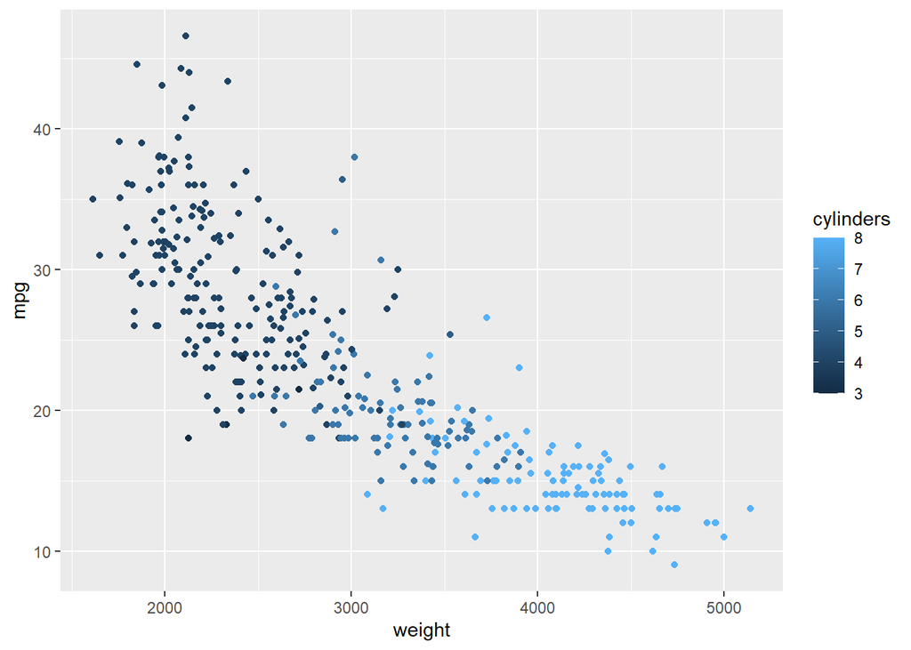

```r
ggplot(Auto1)+geom_point(aes(x=weight,y=mpg, col=cylinders))
```

Output when color is indicated by using cylinders as a factor variable.

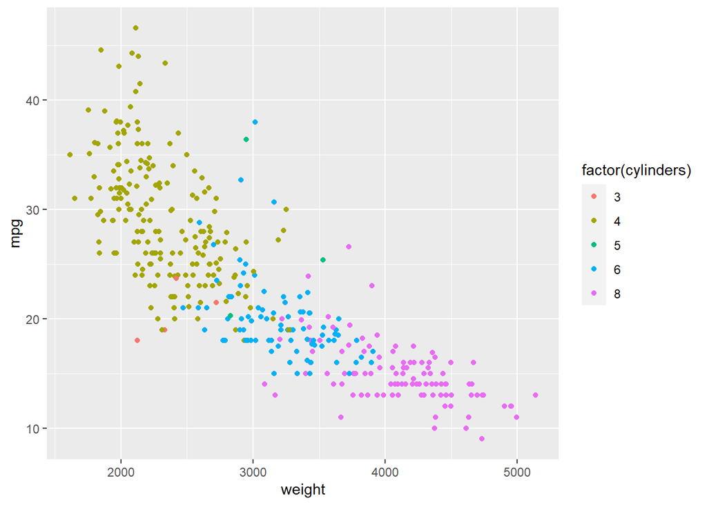

```r
ggplot(Auto1)+geom_point(aes(x=weight,y=mpg, col=factor(cylinders)))
```

- **Exercise 6**: Produce a box plot of `mpg` (y-variable) and `factor(cylinder)` of data imported from `Auto.csv`. Is there anything unexpected on the graph?

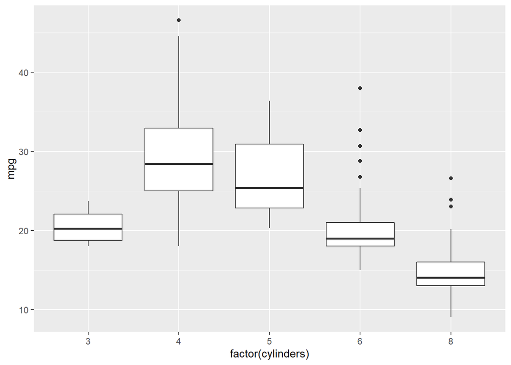

```r
ggplot(Auto1)+geom_boxplot(aes(x=factor(cylinders),y=mpg))
```

It seems to be strange that cars with three cylinders use a lot of fuel compared to cars with 4 cylinders. This can be explained by looking more carefully which cars have three cylinders (sports cars in this data set)

- **Exercise 7**: Often we want to see information about many (or all) variables in a compact form. In base R there is a command `pairs` for displaying pairwise plots, but much more informative information can be obtained with the command `ggpairs()` from `GGally` library. Install the library and look at information about shoesize data set. Do you understand what you see in the plot? Do you see the incorrect observation?

*Solution*

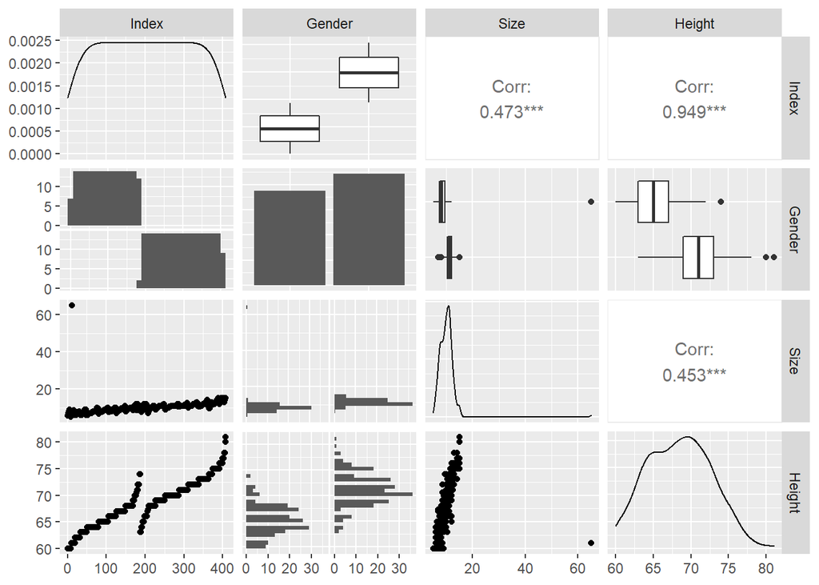

```r
library(GGally)
ggpairs(shoesize,progress=TRUE)
```

There is clearly a very suspicious shoe size larger than 60.

## Data manipulations

Often we need to do something with data before starting to fit models - add variables, add summary statistics, join different tables and so on. Again, there are several possibilities to do that, but we are using commands from `dplyr` package, which is automatically loaded with `library(tidyverse)` command. The logic of this package is that one starts with a data frame (or tibble) and does in sequence several operations (giving output of previous operation as input to the next one) until a desired result is achieved. The operations (like selecting variables, selecting rows, adding new variables, joining data sets and so on) are joined together with `|>` (newer command, available starting from R version 4.1) or `%>%` command and most common operations are

- `select()` for selecting columns
- `filter()` for selecting rows by certain condition
- `group_by` for indicating that next operations are done within some groups
- `mutate()` for adding new variables (possibly by doing computations within groups). See also help for `across()` to see how to apply transformations to many columns with a single mutate command.
- `summarise()` for computing summary information by groups
- `left_join()` for joining data frames by matching some key columns and keeping all rows from the original table
- `ungroup()` for removing grouping information if it was necessary only temporarily

There are many other useful operations.

- **Exercise 8**: Form a new data set `stock_prices` by combining AZN and AMZN datasets by date so that column names have suffixes `.AZN` and `.AMZN`, respectively. Add variable `new` to this dataset, where `new="new"` if date is later than May 31, 2021 and `new="old"` otherwise (use `if_else` command for that). Use this dataset to produce scatterplot of closing prices so that color of points is determined by the variable `new`.

*Solution:*

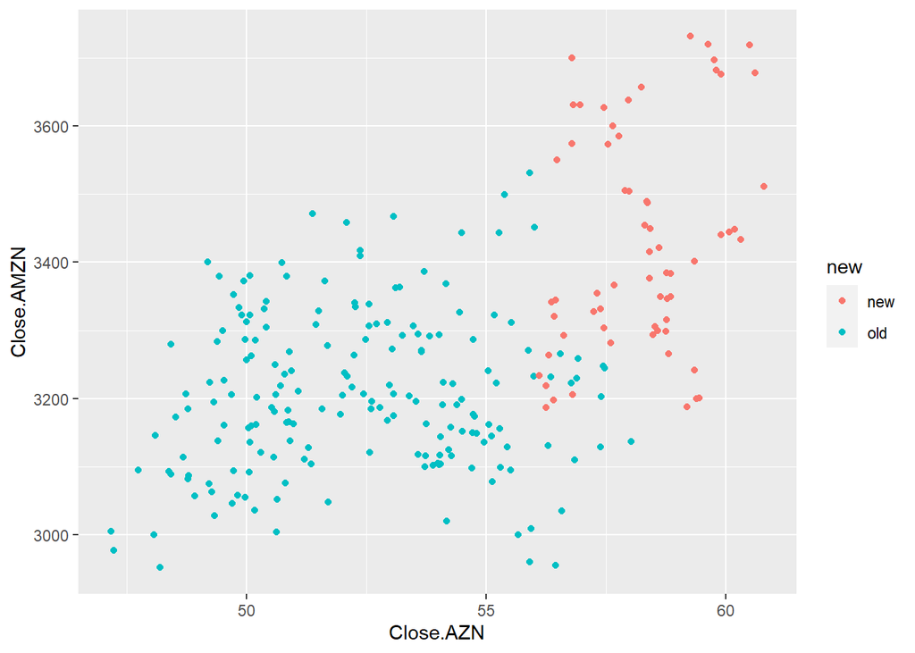

```r
stock_prices=AZN |> left_join(AMZN,by="Date",suffix=c(".AZN",".AMZN")) |> mutate(new=if_else(Date>'2021-05-31',"new","old"))
ggplot(stock_prices)+geom_point(aes(x=Close.AZN,y=Close.AMZN,color=new))
```

- **Exercise 9**: Form a new data set `Auto3` by selecting only `mpg`, `cylinders`, `weight` and adding to the data imported from `Auto.csv` variable `inv_weight` which is computed by `1/weight` and also variable `mean_mpg`, which is average mpg in class with given number of cylinders. Produce scatterplot of `mpg` with respect to `inv_weight`.

*Solution:*

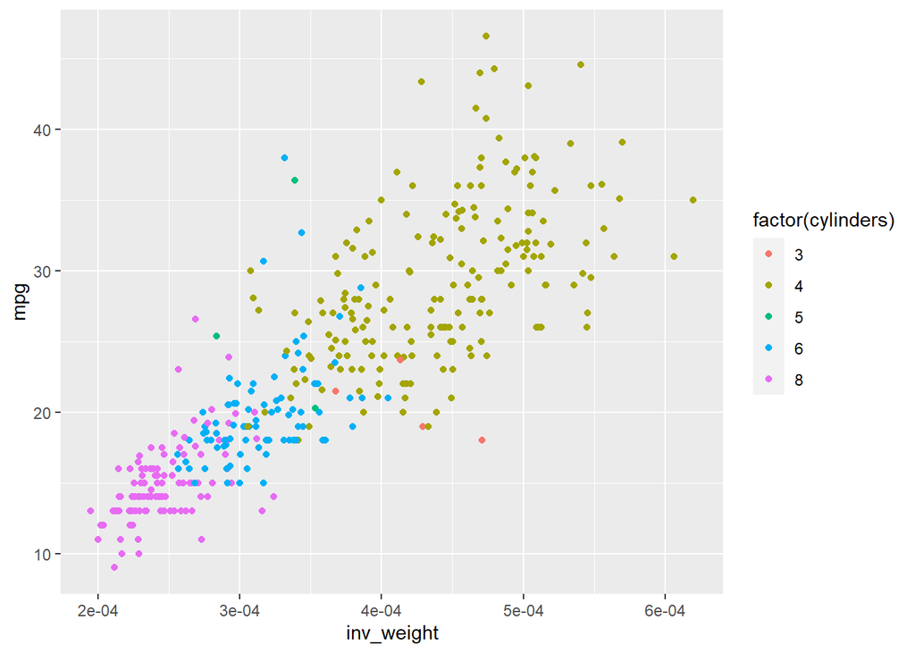

```r
Auto2=Auto1 |>  select(mpg,cylinders,weight) |>  mutate(inv_weight=1/weight) |>  group_by(cylinders) |>  mutate(mean_mpg=mean(mpg))|> ungroup()
ggplot(Auto2)+geom_point(aes(x=inv_weight,y=mpg,color=factor(cylinders)))
```

## Data preprocessing

Often we need to do data manipulation steps repeatedly - for different sets of training data (in order to see how modelling procedure works with different data) before fitting a model and also for new observations before using our model for predictions. All this is possible by using `dplyr` data manipulation commands, but a neater and much more universal way it to use the R package `recipes` for this purpose. This package can be used separately but usually it makes sense to use it together with other related data modelling packages, which can be loaded with `library(tidymodels)`. Let us get some idea how this tool can be used.

A data preprocessing recipe allows one to describe how to expand/modify data set by adding, transforming, imputing or normalizing variables, to prepare the recipe for applying (for example by computing means and standard deviations of variables for normalizing; only training data can be used for that) and to apply the transformation by `bake()` command.

Let us consider preparation of the Auto1 dataset for predictions by creating a recipe which indicates that `mpg` is the response variable and all other except `name` predictor variables, transforms `origin` to a factor variable and normalizes the weight variable.

- **Exercise 10** Perform the following steps:
  - Prepare realistic datasets: all rows without the last one as data available at model fitting time (`Auto1_train`) and one new vector of **x**-variables `Auto1_newx` from the last row with `mpg` removed with commands `Auto1 |> filter(row_number()!=n())` and `Auto1 |> filter(row_number()==n())|>select(-mpg)`
  - define a recipe with data `Auto1_train` and formula `mpg~.`
  - use `step_rm()` to remove variable `name` from data
  - use `step_num2factor()` with levels “one”, “two”, “three” to change `origin` to a factor variable
  - use `sep_normalize()` to standardize the weight variable
  - prepare the recipe for usage by using `prep()` command with option `training=Auto1_train`. This step computes the mean and standard deviation of the `weight`variable, which is used for normalization.
  - create two preprocessed datasets `Auto1_train_preproc` and `Auto1_newx_preproc` by using the recipe with `bake()` command and appropriate datasets.

*Solution:*

```r
Auto1_train=Auto1 |> filter(row_number()!=n())
Auto1_newx=Auto1 |>  filter(row_number()==n()) |> select(-mpg)
rec1=recipe(mpg~., data=Auto1_train) |>
  step_rm(name) |>
  step_num2factor(origin,levels=c("one", "two" ,"three")) |>
  step_normalize(weight)
tidy(rec1)
```

| number | operation | type | trained | skip | id |
| --- | --- | --- | --- | --- | --- |
| 1 | step | rm | FALSE | FALSE | rm_pt3v7 |
| 2 | step | num2factor | FALSE | FALSE | num2factor_w2rJA |
| 3 | step | normalize | FALSE | FALSE | normalize_ngB4s |

```r
rec1_prepared=prep(rec1,Auto1_train)
tidy(rec1_prepared)
```

| number | operation | type | trained | skip | id |
| --- | --- | --- | --- | --- | --- |
| 1 | step | rm | TRUE | FALSE | rm_pt3v7 |
| 2 | step | num2factor | TRUE | FALSE | num2factor_w2rJA |
| 3 | step | normalize | TRUE | FALSE | normalize_ngB4s |

```r
Auto1_train_preproc=bake(rec1_prepared,Auto1_train)
Auto1_train_preproc
```

| cylinders | displacement | horsepower | weight | acceleration | year | origin | mpg |
| --- | --- | --- | --- | --- | --- | --- | --- |
| 8 | 307.0 | 130 | 0.6182536083 | 12.0 | 70 | one | 18.0 |
| 8 | 350.0 | 165 | 0.8405044287 | 11.5 | 70 | one | 15.0 |
| 8 | 318.0 | 150 | 0.5382903502 | 11.0 | 70 | one | 18.0 |
| 8 | 304.0 | 150 | 0.5347625594 | 12.0 | 70 | one | 16.0 |
| 8 | 302.0 | 140 | 0.5535774436 | 10.5 | 70 | one | 17.0 |
| 8 | 429.0 | 198 | 1.6025072415 | 10.0 | 70 | one | 15.0 |
| 8 | 454.0 | 220 | 1.6177943349 | 9.0 | 70 | one | 14.0 |
| 8 | 440.0 | 215 | 1.5684052637 | 8.5 | 70 | one | 14.0 |
| 8 | 455.0 | 225 | 1.7012853839 | 10.0 | 70 | one | 14.0 |
| 8 | 390.0 | 190 | 1.0251254805 | 8.5 | 70 | one | 15.0 |

[output cut: 381 more lines]

```r
Auto1_newx_preproc=bake(rec1_prepared,Auto1_newx)
Auto1_newx_preproc
```

| cylinders | displacement | horsepower | weight | acceleration | year | origin |
| --- | --- | --- | --- | --- | --- | --- |
| 4 | 119 | 82 | -0.3036757 | 19.4 | 82 | one |